# Aula 5 - Econometria de Séries Temporais

Autor

João Ricardo F. de Lima

Data de Publicação

4 de março de 2025

# Raiz Unitária

Considere um processo AR(1)

$$Y_t=\phi_1Y_{t-1}+\epsilon_t
\tag{1}$$

se $\phi_1=1$, tem-se que
$$Y_t=Y_{t-1}+\epsilon_t
\tag{2}$$

ou seja, $Y_t$ é um passeio aleatório, não estacionário, possui uma raiz unitária. Contudo, a existência da raiz unitária não é devido o fato de $\phi_1=1$ no modelo (1) acima. Está relacionado com as raízes de um polinômio;

Usando o operador de defasagem na equação (1), tem-se

$$Y_t=\phi_1LY_t+\epsilon_t
\tag{3}$$

rearranjando os termos

$$Y_t-\phi_1LY_t=\epsilon_t
\tag{4}$$

$$(1-\phi_1L)Y_t=\epsilon_t
\tag{5}$$

em que $1-\phi_1L=0$ é denominada de equação característica/polinômio 1 grau.

Resolvendo para L,
$$\phi_1L=1
\tag{6}$$

$$L=\frac{1}{\phi_1}
\tag{7}$$

denominada de raiz da equação. Identificar se existe raiz unitária no AR(1) é saber se L=1. No AR(1), L=1 quando $\phi_1=1$. Se $\phi_1=1$, L=1 e o processo possui raiz unitária;

Se $|\phi_1|<1$, $|L|>1$, a raiz está fora do círculo unitário, não possui raiz unitária, a série é estacionária;

Se $|\phi_1|>1$, $|L|<1$, a série é dita explosiva, não estacionária, sem interesse para análise.

## Conceito de Integração

Uma série não estacionária possui comportamento de passeio aleatório, que é representado pela presença de raízes unitárias na equação característica da série. Esta, para se tornar estacionária, precisa ser diferenciada tantas vezes quanto for o número de raízes unitárias. Assim, tem-se o conceito de *séries integradas*;

Uma série é integrada de ordem d, designada por $Y_t \sim I(d)$, se for necessário diferenciá-la d vezes para torná-la estacionária;

## Propriedades de Séries Integradas

Considere três séries $X_t, Y_t$ e $Z_t$. Tem-se as seguintes propriedades de séries integradas:

1. Se $X_t \sim I(0)$ e $Y_t \sim I(1)$, então $Z_t=X_t+Y_t \sim I(1)$, isto é, uma combinação linear de séries estacionárias e não estacionárias é não estacionária;
2. Se $X_t \sim I(d)$, então $Z_t=a+bX_t \sim I(d)$, onde a e b são constantes. Em outras palavras, uma combinação linear de uma série I(d) também é uma série I(d);
3. Se $X_t \sim I(d_1)$ e $Y_t \sim I(d_2)$ com $d_1 < d_2$, então, $Z_t=aX_t+bY_t \sim I(d_2)$
4. Se $X_t \sim I(d)$ e $Y_t \sim I(d)$, então, $Z_t=aX_t+bY_t \sim I(d^*)$; $d^*$ em geral é igual a d, mas em alguns casos $d^* \leq d$.

## Determinação da Estacionariedade

Para identificar se uma série possui raiz unitária, deve-se realizar testes específicos desenvolvidos com esta finalidade. Existem diversos: DF (Dickey-Fuller), ADF (Dickey-Fuller aumentado), DF-GLS (Dickey-Fuller por minimos quadrados generalizados); Phillips-Perron, KPSS, etc.

Apresentamos aqui apenas o DF, ADF e o DF-GLS, que são os mais usados. No DF, considere um processo autorregressivo de ordem p, dado por:

$$y_t=\rho y_{t-1}+\epsilon_t$$
em que $\epsilon_t$ é um termo ruído branco, ou seja, possui média zero e variância constante. O que se deseja testar é se $\rho=1$, ou seja, y possui raiz unitária, sendo não estacionário. Perceba que com $\rho=1$ o processo AR acima se torna um passeio aleatório sem constante e todo PA é por definição não estacionário. Por conveniência estatística o teste é conduzido com a equação em primeira diferença.

$$y_t-y_{t-1}=\rho y_{t-1}-y_{t-1}+\epsilon_t$$
$$\Delta y_t=(\rho-1)y_{t-1}+\epsilon_t$$

$$\Delta y_t=\delta y_{t-1}+\epsilon_t$$

em que $\delta=\rho-1$. Se $\rho=1$, $\delta=0$. Desta forma, $\Delta y$ seria igual a um ruído branco, estacionário.

Assim, a hipótese nula do teste é que $\delta=0$, ou seja, $\rho=1$ e a série possui raiz unitária, sendo estacionária na primeira diferença;

A significância de $\delta$ segue uma distribuição tabulada por Dickey e Fuller denominada de $\tau$.

No teste, é possível definir na equação de teste se a mesma possui intercepto e tendência. No ADF, considere um processo autorregressivo de ordem p, dado por:

$$\Delta y_t=\delta y_{t-1}+ \sum_{j=1}^{p-1} \rho_{j+1} \Delta y_{t-j}+\epsilon_t$$

A diferença entre o DF e o ADF está na inclusão de termos de diferença defasados ($\Delta y_{t-j}$).

O objetivo de incluir estes termos de diferença defasados é tornar os erros serialmente independentes, dado que a existência de autocorrelação nos resíduos invalida os valores da distribuição $\tau$.

No mais, a estatística deste teste é a mesma do DF, sendo usado os valores críticos de $\tau$.

A hipótese nula deste teste é a mesma do DF, ou seja, a série possui raiz unitária, sendo não estacionaria.

O teste ADF também pode incluir termos determinísticos de intercepto e tendência. Como o mesmo possui termos de diferença defasados, tem-se o problema de determinar o numero de defasagens p.

Para isto, deve-se usar os critérios de informação de Akaike ou Schwarz disponíveis nos softwares.

# Demonstração no R

## Entrada dos dados

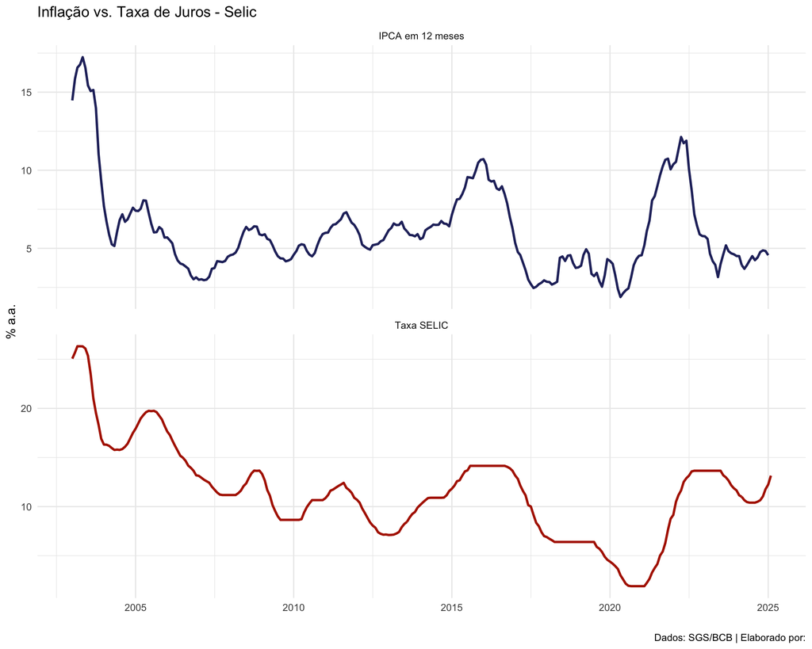

```r
#Direcionado o R para o Diretorio a ser trabalhado
#setwd('/Users/jricardofl/Dropbox/tempecon/facape/econometria2')

#Pacotes utilizados
library(forecast)
library(ggplot2)
library(urca)
library(tseries)
#library(GetBCBData)
library(magrittr)
library(reshape2)
library(rbcb)
library(dplyr)
library(tidyr)

selic_ipca <- rbcb::get_series(
    c("IPCA em 12 meses" = 13522, "Taxa SELIC" = 4189),
    start_date = "2003-01-01",
    as = "tibble")

# Correctly combining the two tibbles
selic_ipca <- bind_rows(
  selic_ipca$`IPCA em 12 meses` %>%
    rename(value = `IPCA em 12 meses`) %>%
    mutate(variable = "IPCA em 12 meses"),
  selic_ipca$`Taxa SELIC` %>%
    rename(value = `Taxa SELIC`) %>%
    mutate(variable = "Taxa SELIC")
)

# Gráfico com o ggplot2
selic_ipca %>%
  ggplot2::ggplot(ggplot2::aes(x = date, y = value, colour = variable)) +
  ggplot2::geom_line(size = 1) +
  ggplot2::labs(title = "Inflação vs. Taxa de Juros - Selic",
                x = "",
                y = "% a.a.",
                caption = "Dados: SGS/BCB | Elaborado por:") +
  ggplot2::scale_colour_manual(values = c(
             "#282f6b", # blue
             "#b22200" # red
  )) +
  ggplot2::facet_wrap(~variable, nrow = 2, scales = "free_y") +
  ggplot2::theme_minimal()+
  ggplot2::theme(legend.position = "none")
```

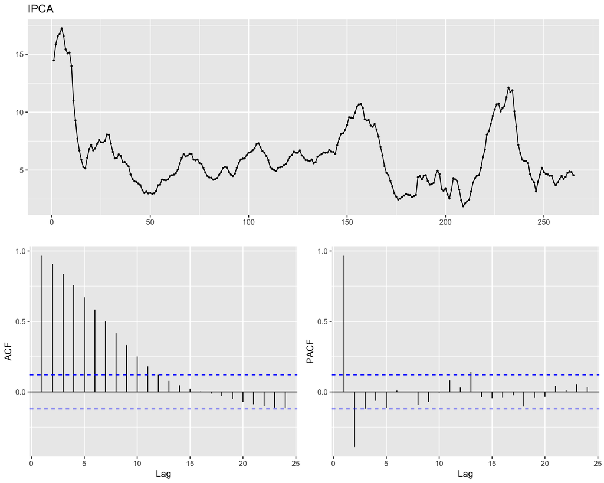

```r
# FAC e FACp
#Visualizando da série, da FAC e da FACp

# Separating the IPCA series
ipca <- selic_ipca %>%
  filter(variable == "IPCA em 12 meses") %>%
  select(date, value) %>%
  rename(IPCA = value)

# Separating the SELIC series
selic <- selic_ipca %>%
  filter(variable == "Taxa SELIC") %>%
  select(date, value) %>%
  rename(Selic = value)

ggtsdisplay(ipca$IPCA, main='IPCA')
```

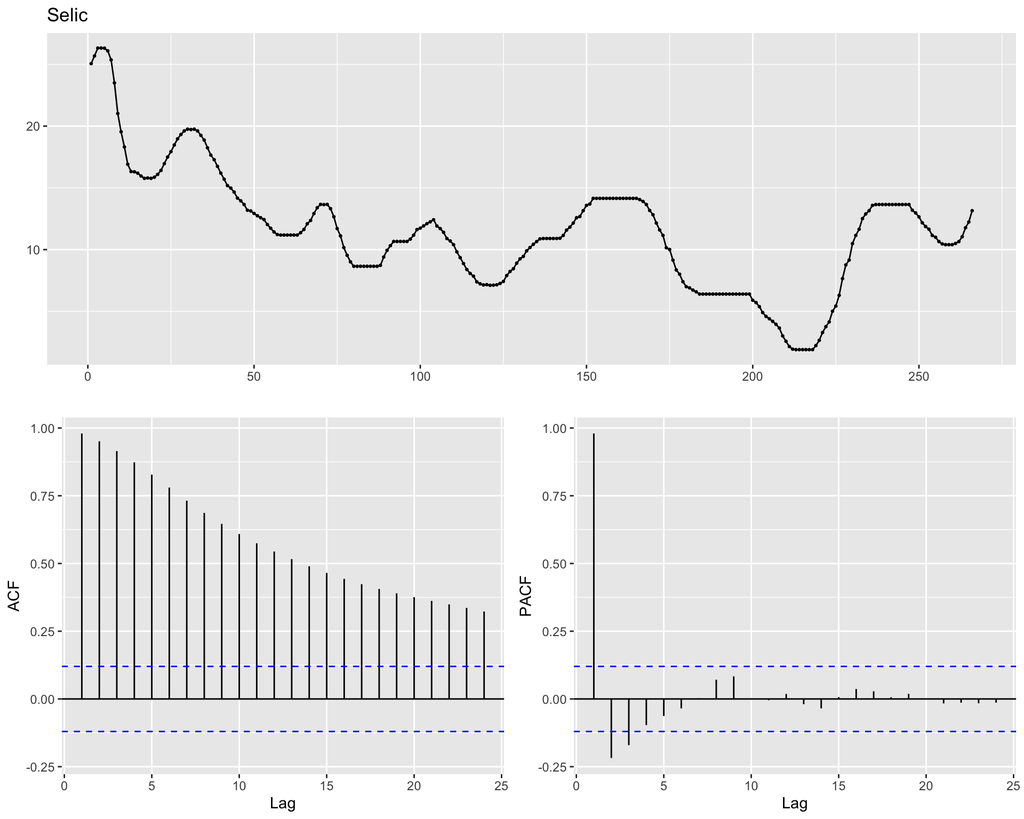

```r
ggtsdisplay(selic$Selic, main='Selic')
```

## Teste de Raiz Unitária DF (Dickey-Fuller)

```r
#Estatistica de Teste DF para IPCA
ipcan.df <- ur.df(ipca$IPCA, type = 'none', lags=0)
summary(ipcan.df)
```

```
###############################################
# Augmented Dickey-Fuller Test Unit Root Test #
###############################################

Test regression none


Call:
lm(formula = z.diff ~ z.lag.1 - 1)

Residuals:
     Min       1Q   Median       3Q      Max
-2.80920 -0.21307  0.07253  0.31147  1.56085

Coefficients:
         Estimate Std. Error t value Pr(>|t|)
z.lag.1 -0.010787   0.004689  -2.301   0.0222 *
---
Signif. codes:  0 '***' 0.001 '**' 0.01 '*' 0.05 '.' 0.1 ' ' 1

Residual standard error: 0.5143 on 263 degrees of freedom
Multiple R-squared:  0.01973,   Adjusted R-squared:  0.016
F-statistic: 5.292 on 1 and 263 DF,  p-value: 0.0222


Value of test-statistic is: -2.3005

Critical values for test statistics:
      1pct  5pct 10pct
tau1 -2.58 -1.95 -1.62
```

```r
ipcad.df <- ur.df(ipca$IPCA, type = 'drift', lags=0)
summary(ipcad.df)
```

```
###############################################
# Augmented Dickey-Fuller Test Unit Root Test #
###############################################

Test regression drift


Call:
lm(formula = z.diff ~ z.lag.1 + 1)

Residuals:
     Min       1Q   Median       3Q      Max
-2.66759 -0.26425  0.02663  0.28137  1.68830

Coefficients:
            Estimate Std. Error t value Pr(>|t|)
(Intercept)  0.16115    0.07472   2.157  0.03194 *
z.lag.1     -0.03244    0.01107  -2.931  0.00368 **
---
Signif. codes:  0 '***' 0.001 '**' 0.01 '*' 0.05 '.' 0.1 ' ' 1

Residual standard error: 0.5108 on 262 degrees of freedom
Multiple R-squared:  0.03175,   Adjusted R-squared:  0.02805
F-statistic: 8.591 on 1 and 262 DF,  p-value: 0.003676


Value of test-statistic is: -2.9311 5.0086

Critical values for test statistics:
      1pct  5pct 10pct
tau2 -3.44 -2.87 -2.57
phi1  6.47  4.61  3.79
```

```r
ipcat.df <- ur.df(ipca$IPCA, type = 'trend', lags=0)
summary(ipcat.df)
```

```
###############################################
# Augmented Dickey-Fuller Test Unit Root Test #
###############################################

Test regression trend


Call:
lm(formula = z.diff ~ z.lag.1 + 1 + tt)

Residuals:
     Min       1Q   Median       3Q      Max
-2.64338 -0.25376  0.02221  0.28448  1.71447

Coefficients:
              Estimate Std. Error t value Pr(>|t|)
(Intercept)  0.1055367  0.1039458   1.015  0.31090
z.lag.1     -0.0304308  0.0113813  -2.674  0.00797 **
tt           0.0003267  0.0004241   0.770  0.44182
---
Signif. codes:  0 '***' 0.001 '**' 0.01 '*' 0.05 '.' 0.1 ' ' 1

Residual standard error: 0.5112 on 261 degrees of freedom
Multiple R-squared:  0.03395,   Adjusted R-squared:  0.02654
F-statistic: 4.586 on 2 and 261 DF,  p-value: 0.01103


Value of test-statistic is: -2.6738 3.5317 4.5857

Critical values for test statistics:
      1pct  5pct 10pct
tau3 -3.98 -3.42 -3.13
phi2  6.15  4.71  4.05
phi3  8.34  6.30  5.36
```

São três diferentes fórmulas para o DF, baseados nas três possibilidade de testes: nenhum, com constante e com tendência. Estas fórmulas levam a três diferentes hipóteses a ser testadas. Em todos os três casos, contudo, se testa se $\delta=0$ (o coeficiente do valor de y defasadado é igual a zero), ou seja, se existe uma raiz unitária.

Assim, para `type="none"`, o output irá mostrar tau1, o valor crítico (com diferentes níveis de significância) para a hipótese nula de $\delta=0$.

Para `type="drift"`, tau2 é o valor crítico para o teste de $\delta=0$. phi1 se refere a segunda hipótese, que é a hipótese nula combinada de que a constante $a_0=\delta=0$, ou seja, ambos valores são testados para ser iguais a zero ao mesmo tempo.

Finalmente, para `type="trend"` as hipóteses testadas são $tau3:\delta=0$; $phi3:\delta=a_2=0$, com $a_2$ igual ao coeficiente da tendência e $phi2:a_0=\delta=a_2=0$.

## Teste de Raiz Unitária ADF (Dickey-Fuller Aumentado)

```r
#Estatistica de Teste ADF para IPCA
ipcan.adf <- ur.df(ipca$IPCA, type = 'none', selectlags='AIC')
summary(ipcan.adf)
```

```
###############################################
# Augmented Dickey-Fuller Test Unit Root Test #
###############################################

Test regression none


Call:
lm(formula = z.diff ~ z.lag.1 - 1 + z.diff.lag)

Residuals:
     Min       1Q   Median       3Q      Max
-2.15245 -0.13163  0.07264  0.26107  1.50045

Coefficients:
            Estimate Std. Error t value Pr(>|t|)
z.lag.1    -0.009855   0.003768  -2.616  0.00942 **
z.diff.lag  0.577393   0.048652  11.868  < 2e-16 ***
---
Signif. codes:  0 '***' 0.001 '**' 0.01 '*' 0.05 '.' 0.1 ' ' 1

Residual standard error: 0.4088 on 261 degrees of freedom
Multiple R-squared:  0.3683,    Adjusted R-squared:  0.3635
F-statistic:  76.1 on 2 and 261 DF,  p-value: < 2.2e-16


Value of test-statistic is: -2.6157

Critical values for test statistics:
      1pct  5pct 10pct
tau1 -2.58 -1.95 -1.62
```

```r
ipcad.adf <- ur.df(ipca$IPCA, type = 'drift', selectlags='AIC')
summary(ipcad.adf)
```

```
###############################################
# Augmented Dickey-Fuller Test Unit Root Test #
###############################################

Test regression drift


Call:
lm(formula = z.diff ~ z.lag.1 + 1 + z.diff.lag)

Residuals:
    Min      1Q  Median      3Q     Max
-1.9494 -0.1773 -0.0059  0.2170  1.3651

Coefficients:
             Estimate Std. Error t value Pr(>|t|)
(Intercept)  0.219934   0.058989   3.728 0.000237 ***
z.lag.1     -0.039637   0.008794  -4.507 9.94e-06 ***
z.diff.lag   0.583110   0.047517  12.272  < 2e-16 ***
---
Signif. codes:  0 '***' 0.001 '**' 0.01 '*' 0.05 '.' 0.1 ' ' 1

Residual standard error: 0.3991 on 260 degrees of freedom
Multiple R-squared:  0.3962,    Adjusted R-squared:  0.3915
F-statistic: 85.29 on 2 and 260 DF,  p-value: < 2.2e-16


Value of test-statistic is: -4.5073 10.5404

Critical values for test statistics:
      1pct  5pct 10pct
tau2 -3.44 -2.87 -2.57
phi1  6.47  4.61  3.79
```

```r
ipcat.adf <- ur.df(ipca$IPCA, type = 'trend', selectlags='AIC')
summary(ipcat.adf)
```

```
###############################################
# Augmented Dickey-Fuller Test Unit Root Test #
###############################################

Test regression trend


Call:
lm(formula = z.diff ~ z.lag.1 + 1 + tt + z.diff.lag)

Residuals:
     Min       1Q   Median       3Q      Max
-1.94645 -0.17286 -0.00291  0.21912  1.36363

Coefficients:
              Estimate Std. Error t value Pr(>|t|)
(Intercept)  2.119e-01  8.174e-02   2.592   0.0101 *
z.lag.1     -3.936e-02  9.024e-03  -4.362 1.87e-05 ***
tt           4.758e-05  3.340e-04   0.142   0.8868
z.diff.lag   5.825e-01  4.781e-02  12.182  < 2e-16 ***
---
Signif. codes:  0 '***' 0.001 '**' 0.01 '*' 0.05 '.' 0.1 ' ' 1

Residual standard error: 0.3998 on 259 degrees of freedom
Multiple R-squared:  0.3962,    Adjusted R-squared:  0.3892
F-statistic: 56.65 on 3 and 259 DF,  p-value: < 2.2e-16


Value of test-statistic is: -4.3616 7.0072 10.1298

Critical values for test statistics:
      1pct  5pct 10pct
tau3 -3.98 -3.42 -3.13
phi2  6.15  4.71  4.05
phi3  8.34  6.30  5.36
```

## Teste de Raiz Unitária Phillips-Perron e KPSS

```r
#Estatistica de Teste PP para IPCA
ipca.pp <- ur.pp(ipca$IPCA, type = 'Z-tau', model="trend", lags='short')
summary(ipca.pp)
```

```
##################################
# Phillips-Perron Unit Root Test #
##################################

Test regression with intercept and trend


Call:
lm(formula = y ~ y.l1 + trend)

Residuals:
     Min       1Q   Median       3Q      Max
-2.64338 -0.25376  0.02221  0.28448  1.71447

Coefficients:
             Estimate Std. Error t value Pr(>|t|)
(Intercept) 0.1486635  0.0765169   1.943   0.0531 .
y.l1        0.9695692  0.0113813  85.190   <2e-16 ***
trend       0.0003267  0.0004241   0.770   0.4418
---
Signif. codes:  0 '***' 0.001 '**' 0.01 '*' 0.05 '.' 0.1 ' ' 1

Residual standard error: 0.5112 on 261 degrees of freedom
Multiple R-squared:  0.9669,    Adjusted R-squared:  0.9667
F-statistic:  3815 on 2 and 261 DF,  p-value: < 2.2e-16


Value of test-statistic, type: Z-tau  is: -3.1708

           aux. Z statistics
Z-tau-mu             -0.1920
Z-tau-beta            0.1657

Critical values for Z statistics:
                     1pct      5pct     10pct
critical values -3.996121 -3.428155 -3.137168
```

```r
#Estatistica de Teste KPSS para IPCA
ipca.kpss <- ur.kpss(ipca$IPCA, type = 'tau', lags='short')
summary(ipca.kpss)
```

```
#######################
# KPSS Unit Root Test #
#######################

Test is of type: tau with 5 lags.

Value of test-statistic is: 0.1747

Critical value for a significance level of:
                10pct  5pct 2.5pct  1pct
critical values 0.119 0.146  0.176 0.216
```

# Determinação da Estacionariedade

Um teste de segunda geração, mais poderoso e, por isto, aconselhado a ser usado, é o DF-GLS. O teste DF-GLS é uma versão modificada do teste ADF. A diferença é devido a uma alteração na série por meio de uma regressão por Mínimos Quadrados Generalizados (MQG) antes de executar o teste ADF.

Esse teste foi desenvolvido por Elliot et al. (1996), sugerindo uma mudança no ADF, em que retira-se as variáveis explicativas relativas a tendência determinística (constante e coeficientes de tendência), por meio de uma diferenciação na série. Existem duas possíveis hipóteses alternativas: a série é estacionária em torno de uma tendência linear ou é estacionária sem uma tendência linear.

Com relação a primeira alternativa, o teste DF-GLS é realizado inicialmente estimando o intercepto e a tendência via MQG, incluindo novas variáveis $\tilde{y}, x_t$ e $z_t$, em que

$$\tilde{y}=\left\{\begin{array}{rcc}
y_t &\mbox{se} & t=1 \\
y_t-ay_{t-1} & & t>1.
\end{array}\right.$$
$$x_t=\left\{\begin{array}{rcc}
1 &\mbox{se} & t=1 \\
1-a & & t>1.
\end{array}\right.$$

$$z_t=\left\{\begin{array}{rcc}
1 &\mbox{se} & t=1 \\
t-a(t-1) & & t>1.
\end{array}\right.$$

e $a=1-\frac{13,5}{T}$

Estima-se, então, uma regressão por MQO

$$\tilde{y}=\delta_0x_t+\delta_1z_t+\epsilon_t$$
os estimadores $\hat{\delta_0}$ e $\hat{\delta_1}$ são usados para se retirar a tendência dos dados, gerando uma nova série $y^*_t$. O passo seguinte é estimar um ADF na variável transformada

$$\Delta y^*_t=\alpha+\beta y^*_{t-1}+ \sum_{j=1}^{k}\xi_j\Delta y^*_{t-j}+\epsilon_t$$
e verificar se $\beta=0$

No caso da segunda hipótese alternativa $a=1-\frac{7}{T}$, se elimina z da regressão (1) e estima (2) sobre a variável transformada, verificando se $\beta=0$. Os lags são escolhidos pelo critério de Schwarz $=[12(\frac{T}{100})^{1/4}]$ .

## Estimação do DF-GLS no R

```r
#Verificaçao da Estacionariedade das séries
#Teste de raiz unitaria DF-GLS
#Definção do numero máximo de lags
print(12*(length(ipca$IPCA)/100)^(1/4))
```

```
[1] 15.31062
```

```r
print(12*(length(selic$Selic)/100)^(1/4))
```

```
[1] 15.32504
```

```r
#Estatistica de Teste DFGLS para IPCA Com Constante

ipcaC.dfgls <- ur.ers(ipca$IPCA, type = c("DF-GLS"),
                        model = c("constant"),
                        lag.max = 15)
summary(ipcaC.dfgls)
```

```
###############################################
# Elliot, Rothenberg and Stock Unit Root Test #
###############################################

Test of type DF-GLS
detrending of series with intercept


Call:
lm(formula = dfgls.form, data = data.dfgls)

Residuals:
    Min      1Q  Median      3Q     Max
-1.7446 -0.2200 -0.0158  0.1664  1.2938

Coefficients:
               Estimate Std. Error t value Pr(>|t|)
yd.lag        -0.001609   0.002993  -0.538  0.59143
yd.diff.lag1   0.507458   0.065183   7.785 2.27e-13 ***
yd.diff.lag2   0.056795   0.073100   0.777  0.43798
yd.diff.lag3   0.003772   0.072104   0.052  0.95833
yd.diff.lag4   0.028575   0.065587   0.436  0.66347
yd.diff.lag5  -0.035832   0.065392  -0.548  0.58425
yd.diff.lag6  -0.018182   0.062077  -0.293  0.76986
yd.diff.lag7   0.010195   0.062052   0.164  0.86963
yd.diff.lag8   0.013795   0.061488   0.224  0.82268
yd.diff.lag9   0.078858   0.061528   1.282  0.20123
yd.diff.lag10  0.123749   0.061422   2.015  0.04508 *
yd.diff.lag11 -0.035107   0.061875  -0.567  0.57100
yd.diff.lag12 -0.425216   0.061508  -6.913 4.51e-11 ***
yd.diff.lag13  0.175887   0.067384   2.610  0.00964 **
yd.diff.lag14 -0.047367   0.068341  -0.693  0.48894
yd.diff.lag15  0.091414   0.058200   1.571  0.11761
---
Signif. codes:  0 '***' 0.001 '**' 0.01 '*' 0.05 '.' 0.1 ' ' 1

Residual standard error: 0.3398 on 233 degrees of freedom
Multiple R-squared:  0.4478,    Adjusted R-squared:  0.4099
F-statistic: 11.81 on 16 and 233 DF,  p-value: < 2.2e-16


Value of test-statistic is: -0.5375

Critical values of DF-GLS are:
                 1pct  5pct 10pct
critical values -2.57 -1.94 -1.62
```

```r
#Estatistica de Teste DFGLS para IPCA Com Tendência

ipcaT.dfgls <- ur.ers(ipca$IPCA, type = c("DF-GLS"),
                     model = c("trend"),
                     lag.max = 15)
summary(ipcaT.dfgls)
```

```
###############################################
# Elliot, Rothenberg and Stock Unit Root Test #
###############################################

Test of type DF-GLS
detrending of series with intercept and trend


Call:
lm(formula = dfgls.form, data = data.dfgls)

Residuals:
     Min       1Q   Median       3Q      Max
-1.66658 -0.20315 -0.01287  0.19576  1.30613

Coefficients:
               Estimate Std. Error t value Pr(>|t|)
yd.lag        -0.010375   0.005687  -1.824  0.06937 .
yd.diff.lag1   0.507099   0.064755   7.831 1.70e-13 ***
yd.diff.lag2   0.061258   0.072707   0.843  0.40035
yd.diff.lag3   0.010500   0.071734   0.146  0.88376
yd.diff.lag4   0.030937   0.065240   0.474  0.63580
yd.diff.lag5  -0.034300   0.065045  -0.527  0.59847
yd.diff.lag6  -0.013743   0.061816  -0.222  0.82426
yd.diff.lag7   0.014241   0.061779   0.231  0.81789
yd.diff.lag8   0.016950   0.061186   0.277  0.78201
yd.diff.lag9   0.081946   0.061223   1.338  0.18204
yd.diff.lag10  0.127925   0.061156   2.092  0.03754 *
yd.diff.lag11 -0.029250   0.061666  -0.474  0.63571
yd.diff.lag12 -0.420171   0.061261  -6.859 6.19e-11 ***
yd.diff.lag13  0.177441   0.067033   2.647  0.00867 **
yd.diff.lag14 -0.043797   0.068012  -0.644  0.52024
yd.diff.lag15  0.098839   0.057937   1.706  0.08935 .
---
Signif. codes:  0 '***' 0.001 '**' 0.01 '*' 0.05 '.' 0.1 ' ' 1

Residual standard error: 0.338 on 233 degrees of freedom
Multiple R-squared:  0.4577,    Adjusted R-squared:  0.4205
F-statistic: 12.29 on 16 and 233 DF,  p-value: < 2.2e-16


Value of test-statistic is: -1.8244

Critical values of DF-GLS are:
                 1pct  5pct 10pct
critical values -3.48 -2.89 -2.57
```

```r
#Estatistica de Teste DFGLS para Selic
selicC.dfgls <- ur.ers(selic$Selic, type = c("DF-GLS"),
                      model = c("constant"),
                      lag.max = 15)
summary(selicC.dfgls)
```

```
###############################################
# Elliot, Rothenberg and Stock Unit Root Test #
###############################################

Test of type DF-GLS
detrending of series with intercept


Call:
lm(formula = dfgls.form, data = data.dfgls)

Residuals:
     Min       1Q   Median       3Q      Max
-0.77046 -0.08999 -0.00288  0.08482  0.56073

Coefficients:
                Estimate Std. Error t value Pr(>|t|)
yd.lag        -0.0003658  0.0009763  -0.375   0.7082
yd.diff.lag1   0.5137072  0.0652138   7.877 1.25e-13 ***
yd.diff.lag2   0.3878457  0.0728509   5.324 2.38e-07 ***
yd.diff.lag3   0.3313841  0.0770049   4.303 2.47e-05 ***
yd.diff.lag4  -0.3498635  0.0796910  -4.390 1.71e-05 ***
yd.diff.lag5  -0.1563834  0.0823180  -1.900   0.0587 .
yd.diff.lag6   0.1296276  0.0818114   1.584   0.1144
yd.diff.lag7   0.0435555  0.0819312   0.532   0.5955
yd.diff.lag8   0.0612519  0.0752560   0.814   0.4165
yd.diff.lag9  -0.0667751  0.0736762  -0.906   0.3657
yd.diff.lag10 -0.0833108  0.0727020  -1.146   0.2530
yd.diff.lag11 -0.0405012  0.0708467  -0.572   0.5681
yd.diff.lag12  0.0120926  0.0690758   0.175   0.8612
yd.diff.lag13  0.0507949  0.0656809   0.773   0.4401
yd.diff.lag14  0.0049404  0.0652560   0.076   0.9397
yd.diff.lag15 -0.0621954  0.0537356  -1.157   0.2483
---
Signif. codes:  0 '***' 0.001 '**' 0.01 '*' 0.05 '.' 0.1 ' ' 1

Residual standard error: 0.1875 on 234 degrees of freedom
Multiple R-squared:  0.7632,    Adjusted R-squared:  0.747
F-statistic: 47.13 on 16 and 234 DF,  p-value: < 2.2e-16


Value of test-statistic is: -0.3747

Critical values of DF-GLS are:
                 1pct  5pct 10pct
critical values -2.57 -1.94 -1.62
```

```r
selicT.dfgls <- ur.ers(selic$Selic, type = c("DF-GLS"),
                      model = c("trend"),
                      lag.max = 15)
summary(selicT.dfgls)
```

```
###############################################
# Elliot, Rothenberg and Stock Unit Root Test #
###############################################

Test of type DF-GLS
detrending of series with intercept and trend


Call:
lm(formula = dfgls.form, data = data.dfgls)

Residuals:
     Min       1Q   Median       3Q      Max
-0.75560 -0.07750  0.01494  0.10311  0.57798

Coefficients:
                Estimate Std. Error t value Pr(>|t|)
yd.lag        -0.0009428  0.0024232  -0.389   0.6976
yd.diff.lag1   0.5165890  0.0652756   7.914 9.93e-14 ***
yd.diff.lag2   0.3901004  0.0729644   5.346 2.13e-07 ***
yd.diff.lag3   0.3319024  0.0771406   4.303 2.48e-05 ***
yd.diff.lag4  -0.3505050  0.0798372  -4.390 1.71e-05 ***
yd.diff.lag5  -0.1563468  0.0824771  -1.896   0.0592 .
yd.diff.lag6   0.1311612  0.0819595   1.600   0.1109
yd.diff.lag7   0.0448415  0.0820949   0.546   0.5854
yd.diff.lag8   0.0607128  0.0754225   0.805   0.4217
yd.diff.lag9  -0.0681850  0.0738857  -0.923   0.3570
yd.diff.lag10 -0.0840623  0.0728710  -1.154   0.2499
yd.diff.lag11 -0.0397792  0.0709861  -0.560   0.5758
yd.diff.lag12  0.0115276  0.0692206   0.167   0.8679
yd.diff.lag13  0.0512871  0.0658248   0.779   0.4367
yd.diff.lag14  0.0053633  0.0653988   0.082   0.9347
yd.diff.lag15 -0.0593048  0.0540328  -1.098   0.2735
---
Signif. codes:  0 '***' 0.001 '**' 0.01 '*' 0.05 '.' 0.1 ' ' 1

Residual standard error: 0.1879 on 234 degrees of freedom
Multiple R-squared:  0.7679,    Adjusted R-squared:  0.752
F-statistic: 48.39 on 16 and 234 DF,  p-value: < 2.2e-16


Value of test-statistic is: -0.3891

Critical values of DF-GLS are:
                 1pct  5pct 10pct
critical values -3.48 -2.89 -2.57
```

```r
#Estatistica de Teste DFGLS para Selic
selicC.dfgls <- ur.ers(selic$Selic, type = c("DF-GLS"),
                      model = c("constant"),
                      lag.max = 5)
summary(selicC.dfgls)
```

```
###############################################
# Elliot, Rothenberg and Stock Unit Root Test #
###############################################

Test of type DF-GLS
detrending of series with intercept


Call:
lm(formula = dfgls.form, data = data.dfgls)

Residuals:
     Min       1Q   Median       3Q      Max
-1.25467 -0.10025 -0.01109  0.08403  0.72982

Coefficients:
               Estimate Std. Error t value Pr(>|t|)
yd.lag       -0.0007905  0.0011590  -0.682 0.495797
yd.diff.lag1  0.6976933  0.0627660  11.116  < 2e-16 ***
yd.diff.lag2  0.1689201  0.0746483   2.263 0.024488 *
yd.diff.lag3  0.3159237  0.0728447   4.337 2.09e-05 ***
yd.diff.lag4 -0.2869560  0.0743321  -3.860 0.000144 ***
yd.diff.lag5 -0.0837107  0.0625431  -1.338 0.181947
---
Signif. codes:  0 '***' 0.001 '**' 0.01 '*' 0.05 '.' 0.1 ' ' 1

Residual standard error: 0.227 on 254 degrees of freedom
Multiple R-squared:  0.7433,    Adjusted R-squared:  0.7373
F-statistic: 122.6 on 6 and 254 DF,  p-value: < 2.2e-16


Value of test-statistic is: -0.6821

Critical values of DF-GLS are:
                 1pct  5pct 10pct
critical values -2.57 -1.94 -1.62
```

```r
selicT.dfgls <- ur.ers(selic$Selic, type = c("DF-GLS"),
                      model = c("trend"),
                      lag.max = 4)
summary(selicT.dfgls)
```

```
###############################################
# Elliot, Rothenberg and Stock Unit Root Test #
###############################################

Test of type DF-GLS
detrending of series with intercept and trend


Call:
lm(formula = dfgls.form, data = data.dfgls)

Residuals:
     Min       1Q   Median       3Q      Max
-1.27625 -0.08539  0.00003  0.09269  0.80282

Coefficients:
              Estimate Std. Error t value Pr(>|t|)
yd.lag       -0.003480   0.002685  -1.296   0.1962
yd.diff.lag1  0.722987   0.058979  12.258  < 2e-16 ***
yd.diff.lag2  0.150341   0.071875   2.092   0.0375 *
yd.diff.lag3  0.299237   0.071864   4.164 4.28e-05 ***
yd.diff.lag4 -0.342347   0.059069  -5.796 1.99e-08 ***
---
Signif. codes:  0 '***' 0.001 '**' 0.01 '*' 0.05 '.' 0.1 ' ' 1

Residual standard error: 0.2267 on 256 degrees of freedom
Multiple R-squared:  0.7392,    Adjusted R-squared:  0.7341
F-statistic: 145.1 on 5 and 256 DF,  p-value: < 2.2e-16


Value of test-statistic is: -1.2958

Critical values of DF-GLS are:
                 1pct  5pct 10pct
critical values -3.48 -2.89 -2.57
```

Para o IPCA com constante ou tendência e 15 lags, em modulo o valor da estatistica de teste é menor do que o valor critico de 10%. Assim, não se pode rejeitar a hipótese nula de que a serie possui raiz unitária.

No caso da SELIC, o valor da estatística de teste também é menor do que o valor crítico, tanto com constante quanto com tendência. Assim, conclui-se que também não pode rejeitar a hipótese nula de que a série possui raiz unitária, ou seja, a série também não é estacionária.

# Processo Tendência e Diferença Estacionário

A não estacionariedade de uma série tem relação com a presença de tendência na série, seja determinística ou estocástica. Se uma série tiver raiz unitária e sua diferenciação torná-la estacionária ela é dita processo estacionário em diferenças. Existem ainda as séries com tendência determinística, denominadas de série tendência estacionária pois flutuam em torno da tendência determinística. Para tornar a série estacionária, deve-se remover a tendência corretamente. Se for determinística, pegando os resíduos de uma regressão que estima a tendência. Se for estocástica, via diferenciação da série;

# Análise no Python

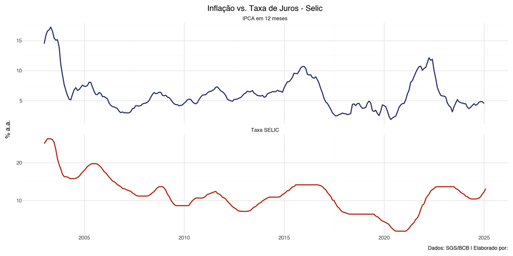

```python
# Import necessary libraries
from bcb import sgs
import pandas as pd
from plotnine import ggplot, aes, geom_line, labs, theme_minimal, theme, scale_color_manual, facet_wrap, scale_x_datetime
import plotnine as p9

# Define the series codes
series = {
    'IPCA em 12 meses': 13522,
    'Taxa SELIC': 4189
}

# Fetch data from 2003-01-01
data = sgs.get(series, start='2003-01-01')

# Redefinir índice para obter 'data' como uma coluna
data = data.reset_index()

# Remodele os dados para o formato longo para plotnine
data_long = pd.melt(data, id_vars=['Date'], var_name='variable', value_name='value')

# Plot usando plotnine
plot = (
    p9.ggplot(data_long, p9.aes(x='Date', y='value', color='variable')) +
    p9.geom_line(size=1) +
    p9.labs(title='Inflação vs. Taxa de Juros - Selic',
            x='',
            y='% a.a.',
            caption='Dados: SGS/BCB | Elaborado por:') +
    p9.scale_color_manual(values=['#282f6b', '#b22200']) +  # Cores Customizadas
    p9.facet_wrap('~variable', nrow=2, scales='free_y') +
    p9.scale_x_datetime(
        breaks=pd.to_datetime(['2005-01-01', '2010-01-01', '2015-01-01', '2020-01-01', '2025-01-01']),
        labels=['2005', '2010', '2015', '2020', '2025']
    ) +
    p9.theme_minimal() +
    p9.theme(
      figure_size=(12, 6),
      legend_position='none'
    )
)

#Exibe o gráfico
plot.show()
```

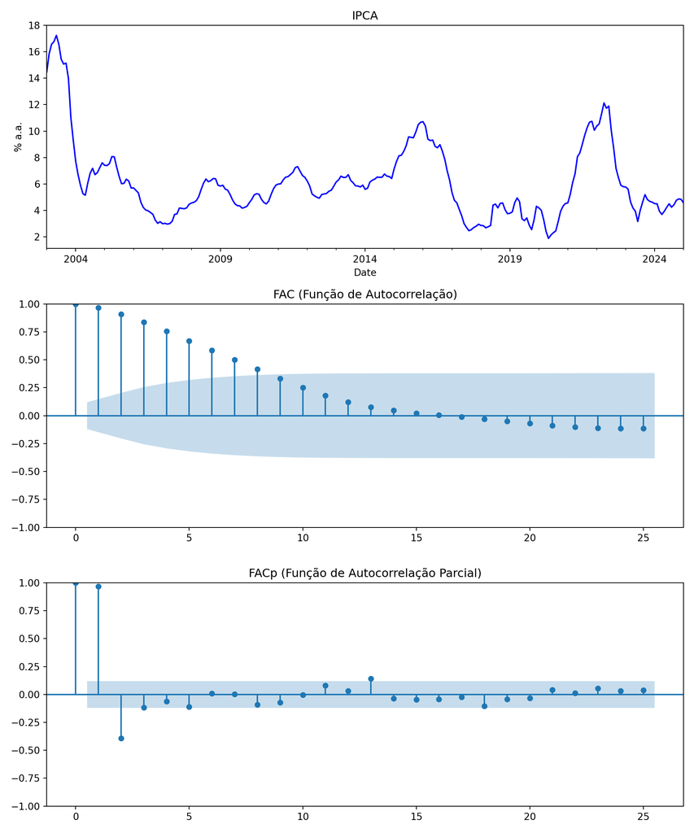

```python
import pandas as pd
import matplotlib.pyplot as plt
from statsmodels.graphics.tsaplots import plot_acf, plot_pacf

# Extrai o IPCA dos dados
ipca = data[['Date', 'IPCA em 12 meses']].copy()
ipca = ipca.rename(columns={'IPCA em 12 meses': 'value'})  # renomeia a coluna
ipca = ipca.dropna()

# Converte a coluna 'Date' para datetime and configura como index
ipca['Date'] = pd.to_datetime(ipca['Date'])
ipca.set_index('Date', inplace=True)

# Plota IPCA, FAC, e FACpa
fig, axes = plt.subplots(3, 1, figsize=(10, 12))

# Plota IPCA
ipca['value'].plot(ax=axes[0], title='IPCA', color='blue')
axes[0].set_ylabel('% a.a.')

# Plota FAC
plot_acf(ipca['value'], ax=axes[1], title='FAC (Função de Autocorrelação)')

# Plota FACp
plot_pacf(ipca['value'], ax=axes[2], title='FACp (Função de Autocorrelação Parcial)', method='ywm')

plt.tight_layout()
plt.show()
```

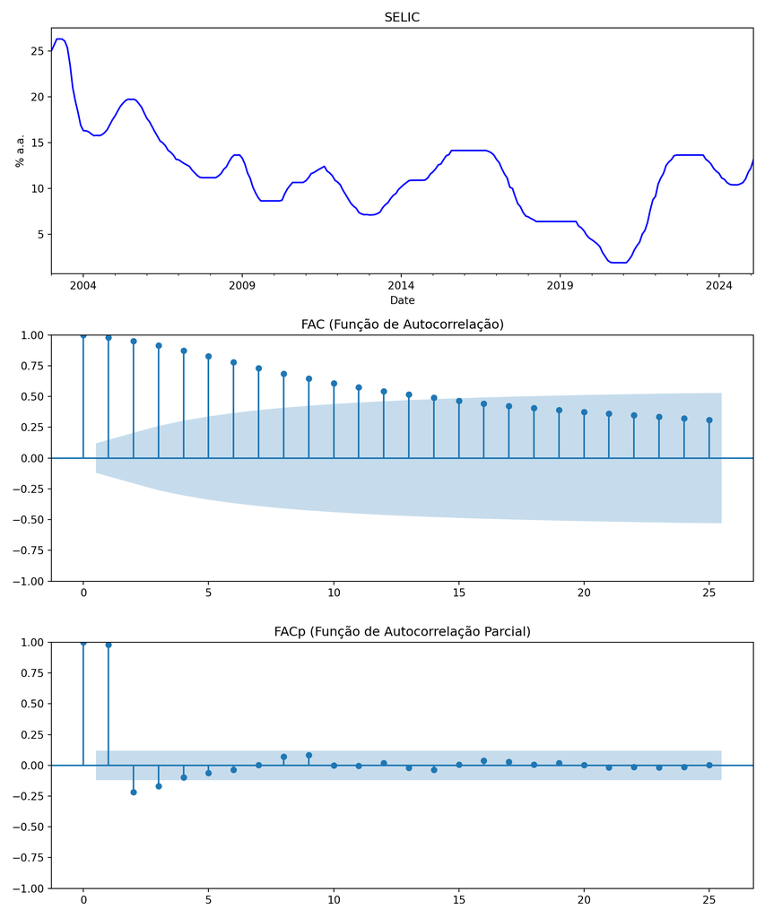

```python
# Extrai SELIC dos dados
selic = data[['Date', 'Taxa SELIC']].copy()
selic = selic.rename(columns={'Taxa SELIC': 'value'})  # Renomeia a coluna
selic = selic.dropna()

# Converte coluna 'Date' para datetime e configura como index
selic['Date'] = pd.to_datetime(selic['Date'])
selic.set_index('Date', inplace=True)

# Plota IPCA FAC e FACp
fig, axes = plt.subplots(3, 1, figsize=(10, 12))

# Plota IPCA
selic['value'].plot(ax=axes[0], title='SELIC', color='blue')
axes[0].set_ylabel('% a.a.')

# Plota FAC
plot_acf(selic['value'], ax=axes[1], title='FAC (Função de Autocorrelação)')

# Plota FACp
plot_pacf(selic['value'], ax=axes[2], title='FACp (Função de Autocorrelação Parcial)', method='ywm')

plt.tight_layout()
plt.show()
```

```python
from statsmodels.tsa.stattools import adfuller

# Executa o teste Dickey-Fuller
result = adfuller(ipca['value'], autolag=None, maxlag=0, regression='n')  # 'c' é o equivalente a 'none' no R

# Exibe os resultados
print("Estatística do Teste Dickey-Fuller: {:.4f}".format(result[0]))
```

```
Estatística do Teste Dickey-Fuller: -2.3005
```

```python
print("p-valor: {:.4f}".format(result[1]))
```

```
p-valor: 0.0206
```

```python
for key, value in result[4].items():
    print('Valor Crítico ({}): {:.4f}'.format(key, value))
```

```
Valor Crítico (1%): -2.5743
Valor Crítico (5%): -1.9421
Valor Crítico (10%): -1.6159
```

```python
# Executa o teste Dickey-Fuller com drift (constante, sem tendência)
result_drift = adfuller(ipca['value'], autolag=None, maxlag=0, regression='c')  # 'c' para constante (drift)

# Exibe os resultados
print("Estatística do Teste Dickey-Fuller (Drift): {:.4f}".format(result_drift[0]))
```

```
Estatística do Teste Dickey-Fuller (Drift): -2.9311
```

```python
print("p-valor: {:.4f}".format(result_drift[1]))
```

```
p-valor: 0.0418
```

```python
for key, value in result_drift[4].items():
    print('Valor Crítico ({}): {:.4f}'.format(key, value))
```

```
Valor Crítico (1%): -3.4554
Valor Crítico (5%): -2.8726
Valor Crítico (10%): -2.5726
```

```python
# Executa o teste Dickey-Fuller com tendência (constante + tendência linear)
result_trend = adfuller(ipca['value'], autolag=None, maxlag=0, regression='ct')  # 'ct' para constante + tendência

# Exibe os resultados
print("Estatística do Teste Dickey-Fuller (Tendência): {:.4f}".format(result_trend[0]))
```

```
Estatística do Teste Dickey-Fuller (Tendência): -2.6738
```

```python
print("p-valor: {:.4f}".format(result_trend[1]))
```

```
p-valor: 0.2471
```

```python
for key, value in result_trend[4].items():
    print('Valor Crítico ({}): {:.4f}'.format(key, value))
```

```
Valor Crítico (1%): -3.9935
Valor Crítico (5%): -3.4273
Valor Crítico (10%): -3.1369
```

```python
# Executa o teste ADF com seleção automática de defasagens pelo AIC e sem constante
result_adf = adfuller(ipca['value'], autolag='AIC', regression='n')  # 'n' para sem constante (equivalente a 'none')

# Exibe os resultados
print("Estatística do Teste ADF: {:.4f}".format(result_adf[0]))
```

```
Estatística do Teste ADF: -1.0289
```

```python
print("p-valor: {:.4f}".format(result_adf[1]))
```

```
p-valor: 0.2766
```

```python
print("Número de defasagens selecionadas: {}".format(result_adf[2]))
```

```
Número de defasagens selecionadas: 13
```

```python
for key, value in result_adf[4].items():
    print('Valor Crítico ({}): {:.4f}'.format(key, value))
```

```
Valor Crítico (1%): -2.5747
Valor Crítico (5%): -1.9421
Valor Crítico (10%): -1.6158
```

```python
# Executa o teste ADF com seleção automática de defasagens pelo AIC e sem constante
result_adf_drift = adfuller(ipca['value'], autolag='AIC', regression='c')  # 'n' para sem constante (equivalente a 'none')

# Exibe os resultados
print("Estatística do Teste ADF: {:.4f}".format(result_adf_drift[0]))
```

```
Estatística do Teste ADF: -2.7034
```

```python
print("p-valor: {:.4f}".format(result_adf_drift[1]))
```

```
p-valor: 0.0735
```

```python
print("Número de defasagens selecionadas: {}".format(result_adf_drift[2]))
```

```
Número de defasagens selecionadas: 13
```

```python
for key, value in result_adf_drift[4].items():
    print('Valor Crítico ({}): {:.4f}'.format(key, value))
```

```
Valor Crítico (1%): -3.4567
Valor Crítico (5%): -2.8731
Valor Crítico (10%): -2.5729
```

```python
# Executa o teste ADF com seleção automática de defasagens pelo AIC e sem constante
result_adf_trend = adfuller(ipca['value'], autolag='AIC', regression='ct')  # 'n' para sem constante (equivalente a 'none')

# Exibe os resultados
print("Estatística do Teste ADF: {:.4f}".format(result_adf_trend[0]))
```

```
Estatística do Teste ADF: -2.7087
```

```python
print("p-valor: {:.4f}".format(result_adf_trend[1]))
```

```
p-valor: 0.2325
```

```python
print("Número de defasagens selecionadas: {}".format(result_adf_trend[2]))
```

```
Número de defasagens selecionadas: 13
```

```python
for key, value in result_adf_trend[4].items():
    print('Valor Crítico ({}): {:.4f}'.format(key, value))
```

```
Valor Crítico (1%): -3.9953
Valor Crítico (5%): -3.4281
Valor Crítico (10%): -3.1374
```

```python
from arch.unitroot import PhillipsPerron

# Executa o teste Phillips-Perron com constante + tendência linear e defasagens curtas
pp_test = PhillipsPerron(ipca['value'], trend='ct', lags=3)  # 'ct' para constante + tendência, lags curtos

# Exibe os resultados
print("Estatística do Teste PP (Z-tau): {:.4f}".format(pp_test.stat))
```

```
Estatística do Teste PP (Z-tau): -3.0266
```

```python
print("p-valor: {:.4f}".format(pp_test.pvalue))
```

```
p-valor: 0.1248
```

```python
print("Número de defasagens usadas: {}".format(pp_test.lags))
```

```
Número de defasagens usadas: 3
```

```python
# Exibe os valores críticos
for key, value in pp_test.critical_values.items():
    print('Valor Crítico ({}): {:.4f}'.format(key, value))
```

```
Valor Crítico (1%): -3.9935
Valor Crítico (5%): -3.4273
Valor Crítico (10%): -3.1369
```

```python
from statsmodels.tsa.stattools import kpss

# Executa o teste KPSS com seleção automática de defasagens
stat, p_value, lags, critical_values = kpss(ipca['value'], regression='ct', nlags='auto')  # 'auto' para defasagens automáticas

# Exibe os resultados
print("Estatística do Teste KPSS: {:.4f}".format(stat))
```

```
Estatística do Teste KPSS: 0.1109
```

```python
print("p-valor: {:.4f}".format(p_value))
```

```
p-valor: 0.1000
```

```python
print("Número de defasagens usadas: {}".format(lags))
```

```
Número de defasagens usadas: 10
```

```python
# Exibe os valores críticos
for key, value in critical_values.items():
    print('Valor Crítico ({}): {:.4f}'.format(key, value))
```

```
Valor Crítico (10%): 0.1190
Valor Crítico (5%): 0.1460
Valor Crítico (2.5%): 0.1760
Valor Crítico (1%): 0.2160
```

```python
from arch.unitroot import DFGLS

# Executa o teste DF-GLS com seleção automática de defasagens
dfgls_test = DFGLS(ipca['value'], lags=None, trend='c')  # 'ct' para constante + tendência. Apenas c = constante.

# Exibe os resultados
print("Estatística do Teste DF-GLS: {:.4f}".format(dfgls_test.stat))
```

```
Estatística do Teste DF-GLS: -0.4065
```

```python
print("p-valor: {:.4f}".format(dfgls_test.pvalue))
```

```
p-valor: 0.5387
```

```python
print("Número de defasagens selecionadas: {}".format(dfgls_test.lags))
```

```
Número de defasagens selecionadas: 13
```

```python
# Exibe os valores críticos
for key, value in dfgls_test.critical_values.items():
    print('Valor Crítico ({}): {:.4f}'.format(key, value))
```

```
Valor Crítico (1%): -2.6469
Valor Crítico (5%): -2.0262
Valor Crítico (10%): -1.7080
```

```python
from arch.unitroot import DFGLS

# Executa o teste DF-GLS com seleção automática de defasagens
dfgls_test = DFGLS(ipca['value'], lags=None, trend='ct')  # 'ct' para constante + tendência. Apenas c = constante.

# Exibe os resultados
print("Estatística do Teste DF-GLS: {:.4f}".format(dfgls_test.stat))
```

```
Estatística do Teste DF-GLS: -1.6337
```

```python
print("p-valor: {:.4f}".format(dfgls_test.pvalue))
```

```
p-valor: 0.5030
```

```python
print("Número de defasagens selecionadas: {}".format(dfgls_test.lags))
```

```
Número de defasagens selecionadas: 13
```

```python
# Exibe os valores críticos
for key, value in dfgls_test.critical_values.items():
    print('Valor Crítico ({}): {:.4f}'.format(key, value))
```

```
Valor Crítico (1%): -3.4930
Valor Crítico (5%): -2.9239
Valor Crítico (10%): -2.6345
```